# Covid 19 Mortalità

Boschi Giulia 804623

1/5/2020

```r
library(dplyr)
library(tidyr)

setwd("C:\\Users\\giuli\\Google Drive\\DS\\Data science lab\\dati-giornalieri-comune")
```

```r
dt <- read.csv("comune_giorno.csv")
```

```r
td <- dt %>% gather(key = "SESSO_ANNO", value = "DECESSI", #diamo dei nomi
                    MASCHI_15:TOTALE_20)
```

```r
td %>% tidyr::separate(SESSO_ANNO, c("SESSO", "ANNO"), "_") -> td
```

```r
td %>% mutate(DATA = as.Date(paste0("0", GE, "20", ANNO), format = "%m%d%Y")) -> td
```

#import td

```r
td <- read.csv("td.csv")
```

#Numero di comuni per regione e data inizio diff

```r
library(plyr)
td %>% dplyr::filter(DECESSI < 9999) %>%
  dplyr::group_by(NOME_REGIONE, DATA_INIZIO_DIFF) %>%
  dplyr::summarise(N_COMUNI = length(unique(NOME_COMUNE)))
```

```
## # A tibble: 77 x 3
## # Groups:   NOME_REGIONE [20]
##    NOME_REGIONE DATA_INIZIO_DIFF N_COMUNI
##    <fct>        <fct>               <int>
##  1 Abruzzo      1 aprile               22
##  2 Abruzzo      8 aprile                6
##  3 Abruzzo      Dati 2020 n.d.        277
##  4 Basilicata   1 aprile                6
##  5 Basilicata   16 aprile               3
##  6 Basilicata   8 aprile                1
##  7 Basilicata   Dati 2020 n.d.        121
##  8 Calabria     1 aprile                8
##  9 Calabria     16 aprile               8
## 10 Calabria     8 aprile                5
## # ... with 67 more rows
```

#Numero di comuni per regione

```r
library(plyr)
td %>% dplyr::filter(DECESSI < 9999) %>%
  dplyr::group_by(NOME_REGIONE) %>%
  dplyr::summarise(N_COMUNI = length(unique(NOME_COMUNE)))
```

```
## # A tibble: 20 x 2
##    NOME_REGIONE                 N_COMUNI
##    <fct>                           <int>
##  1 Abruzzo                           305
##  2 Basilicata                        131
##  3 Calabria                          404
##  4 Campania                          550
##  5 Emilia-Romagna                    328
##  6 Friuli-Venezia Giulia             215
##  7 Lazio                             378
##  8 Liguria                           234
##  9 Lombardia                        1505
## 10 Marche                            228
## 11 Molise                            136
## 12 Piemonte                         1177
## 13 Puglia                            257
## 14 Sardegna                          377
## 15 Sicilia                           390
## 16 Toscana                           273
## 17 Trentino-Alto Adige/Südtirol      282
## 18 Umbria                             92
## 19 Valle d'Aosta/Vallée d'Aoste       74
## 20 Veneto                            563
```

Sono disgiunti

```r
td %>% dplyr::filter(DATA_INIZIO_DIFF != "Dati 2020 n.d.",
              NOME_REGIONE == "Lombardia",
              DECESSI < 9999) -> wdt
```

```r
wdt %>% dplyr::filter(SESSO == "TOTALE") %>%
  dplyr::group_by(DATA, ANNO, NOME_PROVINCIA) %>%
  dplyr::summarise(DECESSI = sum(DECESSI)) %>%
  dplyr::arrange(ANNO, DATA)-> wdt
```

```r
write.csv(wdt, "C:\\Users\\giuli\\Google Drive\\DS\\Data science lab\\dati-giornalieri-comune\\Lombardia.csv", row.names = F)
```

SERIE STORICA MILANO fino al 2019

```r
suppressPackageStartupMessages(library(ggplot2))
suppressPackageStartupMessages(library(forecast))
suppressPackageStartupMessages(library(astsa))
suppressPackageStartupMessages(library(lmtest))
suppressPackageStartupMessages(library(fUnitRoots))
suppressPackageStartupMessages(library(FitARMA))
suppressPackageStartupMessages(library(strucchange))
suppressPackageStartupMessages(library(reshape))
suppressPackageStartupMessages(library(Rmisc))
suppressPackageStartupMessages(library(fBasics))
library(tseries)
library(lubridate)
```

```r
Lombardia <- read.csv("Lombardia.csv", colClasses = c('Date', 'factor', 'character', 'integer'))
```

```r
milano <- Lombardia %>% dplyr::filter(NOME_PROVINCIA == "Milano",  DATA < "2020-01-01")
```

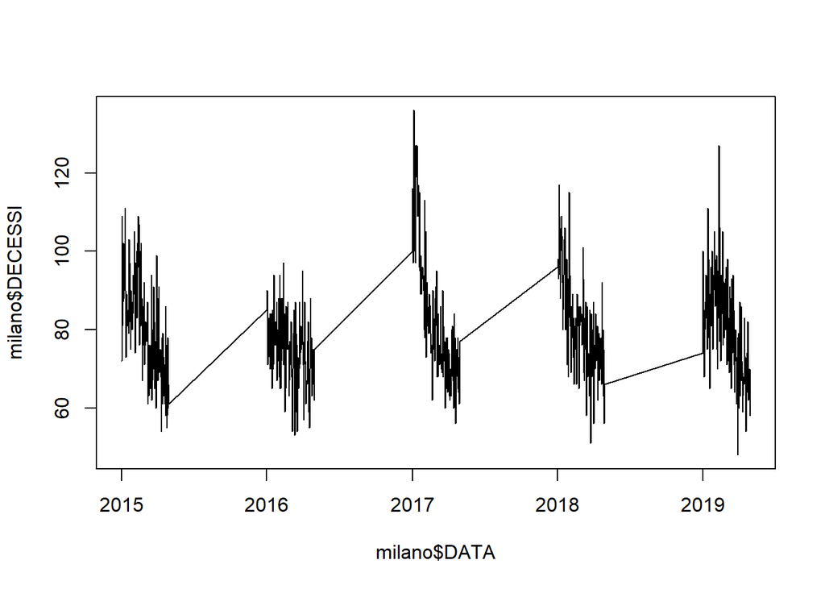

```r
plot(milano$DATA, milano$DECESSI, type = "l")
```

Andamento non stazionario in varianza (valutare una trasformazione logaritmica). Gli ultimi tre anni hanno varianza maggiore rispetto ai primi 2, si osserva che il 2016 è praticamente stazionario se non fosse per la fine del periodo che cala leggermente. 2017 hanno von carianza maggiore (valutiamo se inserire intervento). Escludendo il 2017, il trend non mi sembra particolarmente crescente.

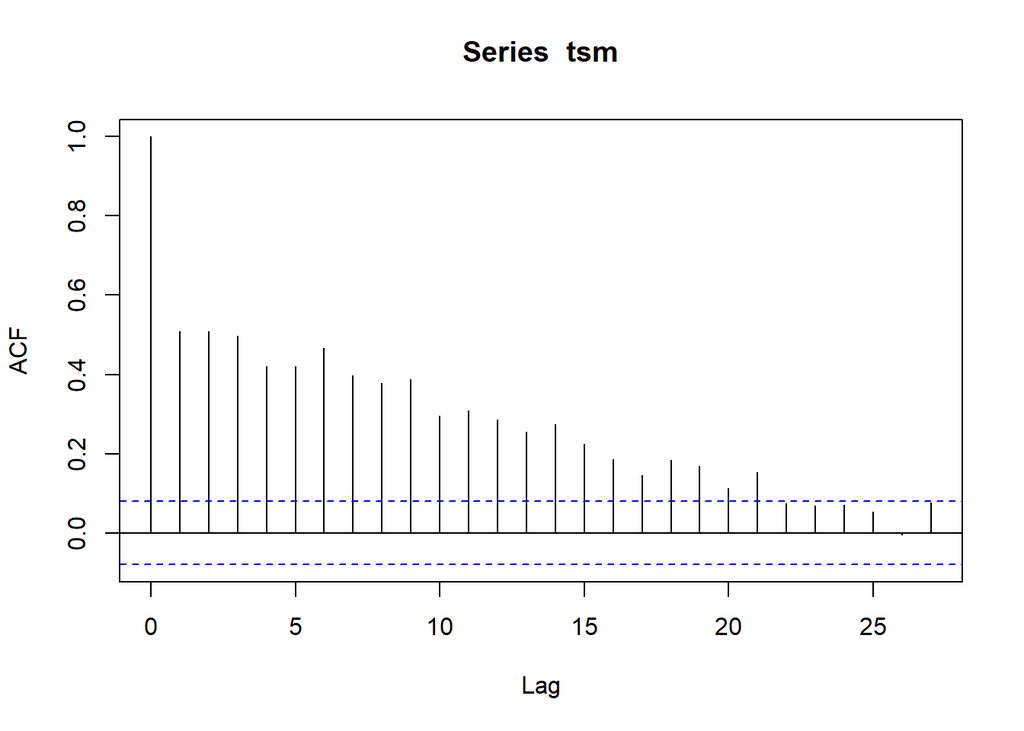

```r
tsm <- ts(milano$DECESSI)

acf(tsm)
```

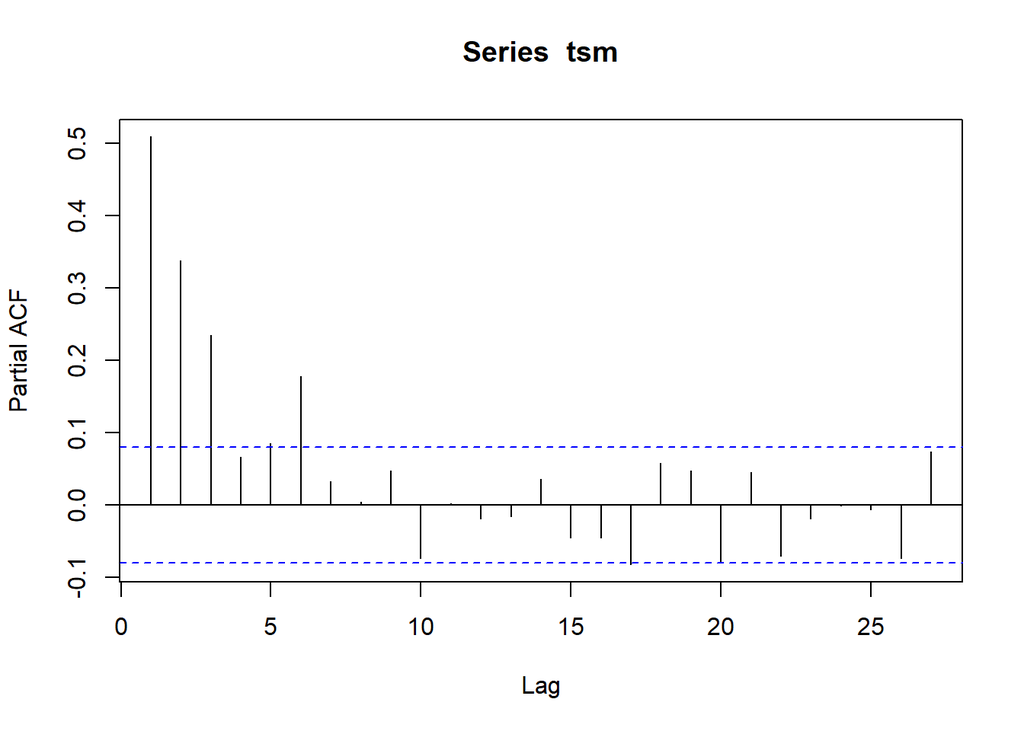

```r
pacf(tsm)
```

Acf si annulla lentamente (sintomi di non stazionarietà), pacf si annulla al terzo lag ma esce per due lag successivi (forse c’è una regolarità). In acf si osserva l’andamento stagionale (onde regolari sui lag, ma di difficile interpretazione data la particolare serie). Da questi correllogrammi direi che c’è della stagionalità che andrebbe corretta, ma non me la sento di fare differenze dato che si tratta di 5 serie separate temporalmente una dall’altra. L’alternativa che si può provare è inserire componenti stagionali SAR e SMA nel modello SARIMA.

```r
adf.test(tsm)
```

```
##
##  Augmented Dickey-Fuller Test
##
## data:  tsm
## Dickey-Fuller = -3.568, Lag order = 8, p-value = 0.03577
## alternative hypothesis: stationary
```

Test di Dickey fuller per capire se la serie presenta una radice unitaria ($|| < 0 $) che comporta la non stazionarietà del modello. Direi che non è stazionaria anche se un po’ al limite. L’obiettivo sarebbe avere un p-val < 0.01, il nostro è 0.04.

#Modello semplicissimo

```r
mod1 <- Arima(tsm, order = c(1, 0, 1))

summary(mod1)
```

```
## Series: tsm
## ARIMA(1,0,1) with non-zero mean
##
## Coefficients:
##          ar1     ma1     mean
##       0.9557  -0.715  79.6093
## s.e.  0.0153   0.034   2.7037
##
## sigma^2 estimated as 113.2:  log likelihood=-2272.88
## AIC=4553.76   AICc=4553.83   BIC=4571.36
##
## Training set error measures:
##                       ME     RMSE      MAE       MPE     MAPE      MASE
## Training set -0.04316825 10.61403 8.304336 -1.798338 10.61566 0.7732156
##                     ACF1
## Training set -0.02895823
```

```r
coeftest(mod1)
```

```
##
## z test of coefficients:
##
##            Estimate Std. Error z value  Pr(>|z|)
## ar1        0.955707   0.015251  62.663 < 2.2e-16 ***
## ma1       -0.714975   0.034013 -21.021 < 2.2e-16 ***
## intercept 79.609332   2.703714  29.444 < 2.2e-16 ***
## ---
## Signif. codes:  0 '***' 0.001 '**' 0.01 '*' 0.05 '.' 0.1 ' ' 1
```

Analisi dei residui

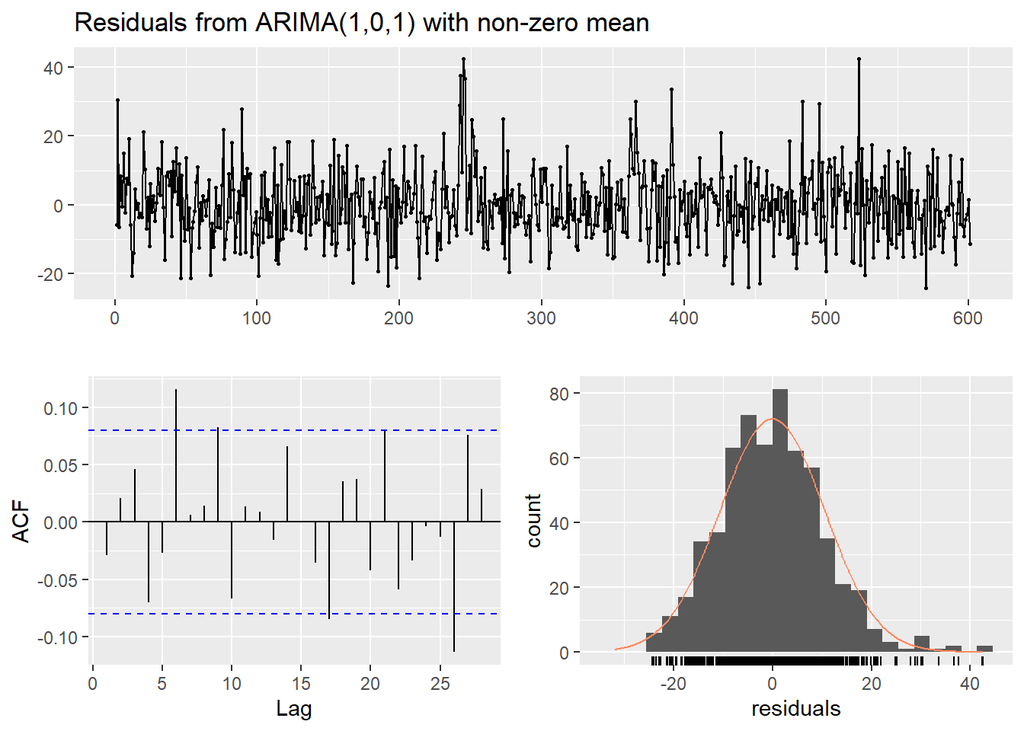

```
##
##  Ljung-Box test
##
## data:  Residuals from ARIMA(1,0,1) with non-zero mean
## Q* = 20.662, df = 7, p-value = 0.004304
##
## Model df: 3.   Total lags used: 10
```

```r
checkresiduals(mod1)
```

```r
#test incorrelazione
LjungBoxTest(residuals(mod1), k = 1, lag.max = 20)
```

```
##   m    Qm     pvalue
##   1  0.51 0.47665538
##   2  0.77 0.38156275
##   3  2.05 0.35835473
##   4  5.03 0.16994624
##   5  5.47 0.24237645
##   6 13.61 0.01829951
##   7 13.63 0.03403315
##   8 13.75 0.05580893
##   9 17.92 0.02181255
##  10 20.66 0.01423926
##  11 20.77 0.02273701
##  12 20.82 0.03525485
##  13 20.98 0.05072616
##  14 23.66 0.03436143
##  15 23.66 0.05027463
##  16 24.44 0.05797673
##  17 28.87 0.02481230
##  18 29.66 0.02892648
##  19 30.54 0.03255845
##  20 31.65 0.03418654
```

```r
#test normalità
jarque.bera.test(residuals(mod1))
```

```
##
##  Jarque Bera Test
##
## data:  residuals(mod1)
## X-squared = 45.188, df = 2, p-value = 1.54e-10
```

Test di Ljung box testa $H_0: \rho_1=\rho_2 = ... = \rho_n = 0$ per vedere se i residui sono incorrelati tra loro e quindi realizzazione di un processo white noise. Il test rifiuta l’ipotesi nulla quindi sono correlati però, guardando i grafici, sembrerebbero white noise (il plot salta su e giù intorno allo 0 e acf è nullo ad eccezione di qualche lag). Quello che fa saltare il test è proprio l’acf che è significativo per qualche lag con una certa “stagionalità”. Ci consiglia di correggerla, ma non sa che non è una vera stagionalità.

Dal test di Jarque-Bera per la normalità ($H_0$: i residui sono realizzazione di una v.c. normale) si deduce che i residui non sono normali (p-val < 0.01). Però, osservando il grafico dei residui e il loro adattamento alla curva della normale, si nota un ottimo adattamento a quest’ultima. Il problema che rileva il test è probabilmente causato dalle code. Non mi preoccuperei della non normalità visto l’adattamento.

#Modello con trasformata logaritmica

```r
BoxCox.lambda(tsm)
```

```
## [1] 0.1390859
```

lambda si avvicina molto di più allo 0 per giustificare una trasformazione

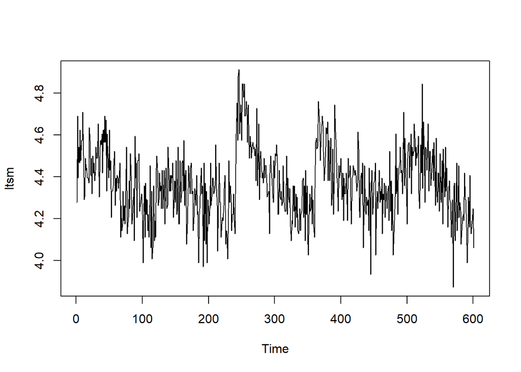

```r
ltsm <- log(tsm)

ts.plot(ltsm)
```

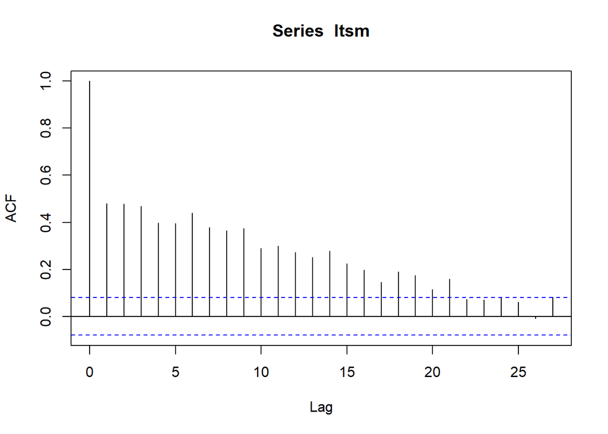

```r
acf(ltsm)
```

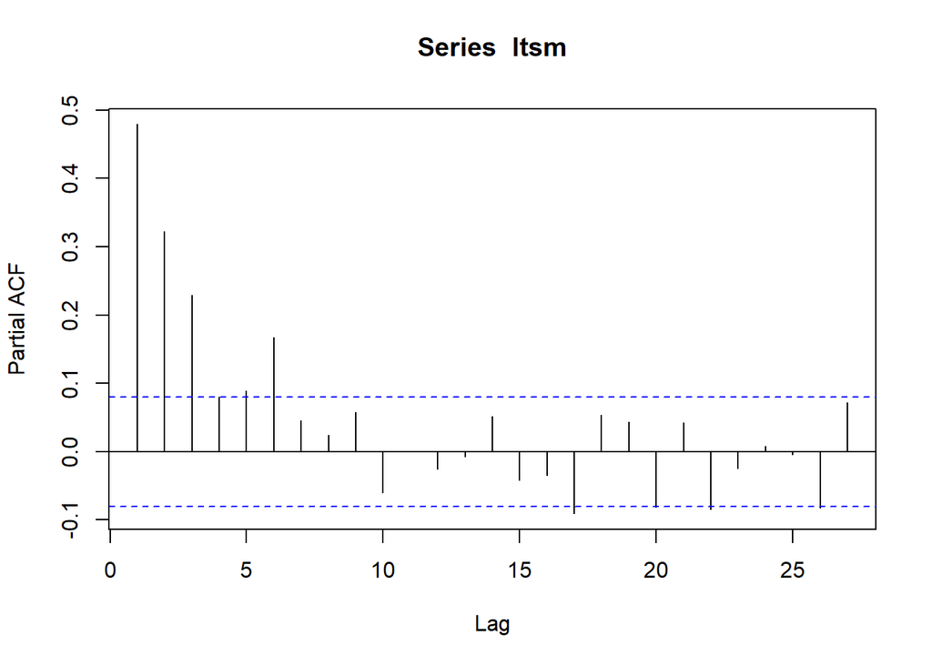

```r
pacf(ltsm)
```

```r
adf.test(ltsm)
```

```
##
##  Augmented Dickey-Fuller Test
##
## data:  ltsm
## Dickey-Fuller = -3.5131, Lag order = 8, p-value = 0.04105
## alternative hypothesis: stationary
```

```r
mod2 <- Arima(ltsm, order = c(1, 0, 1))

summary(mod2)
```

```
## Series: ltsm
## ARIMA(1,0,1) with non-zero mean
##
## Coefficients:
##          ar1      ma1    mean
##       0.9583  -0.7360  4.3613
## s.e.  0.0151   0.0333  0.0331
##
## sigma^2 estimated as 0.0176:  log likelihood=362.2
## AIC=-716.39   AICc=-716.33   BIC=-698.8
##
## Training set error measures:
##                         ME      RMSE       MAE     MPE     MAPE      MASE
## Training set -0.0003719378 0.1323514 0.1046894 -0.1008 2.404511 0.7718645
##                     ACF1
## Training set -0.02382673
```

```r
coeftest(mod2)
```

```
##
## z test of coefficients:
##
##            Estimate Std. Error z value  Pr(>|z|)
## ar1        0.958255   0.015069  63.591 < 2.2e-16 ***
## ma1       -0.736044   0.033282 -22.115 < 2.2e-16 ***
## intercept  4.361283   0.033128 131.650 < 2.2e-16 ***
## ---
## Signif. codes:  0 '***' 0.001 '**' 0.01 '*' 0.05 '.' 0.1 ' ' 1
```

Analisi dei residui

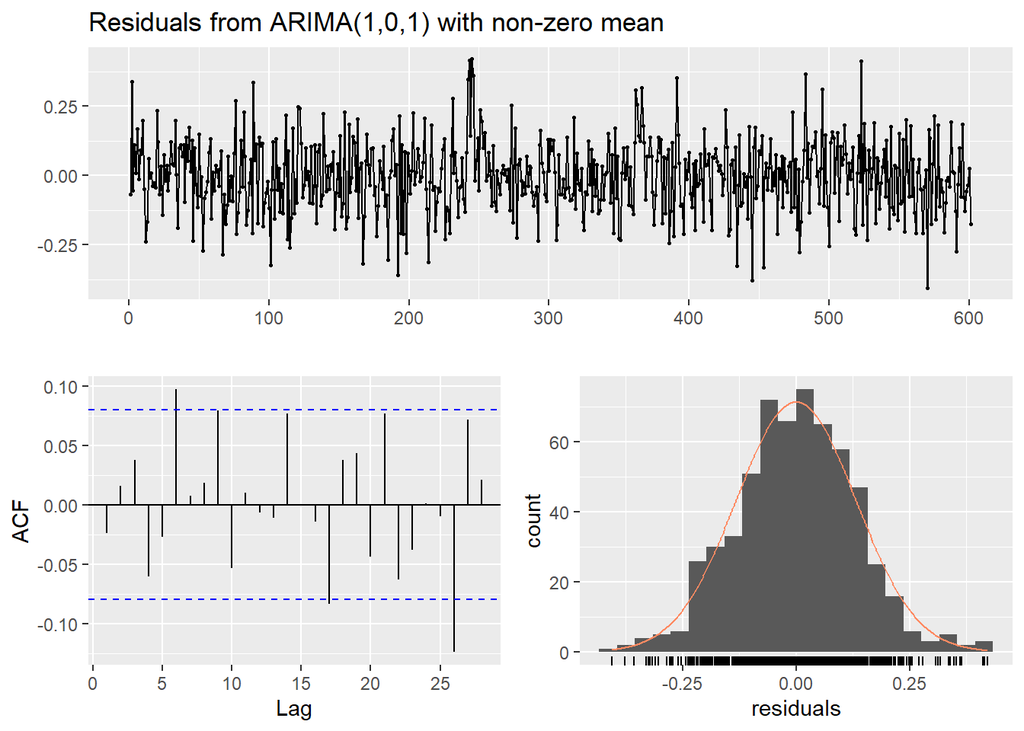

```
##
##  Ljung-Box test
##
## data:  Residuals from ARIMA(1,0,1) with non-zero mean
## Q* = 15.603, df = 7, p-value = 0.029
##
## Model df: 3.   Total lags used: 10
```

```r
checkresiduals(mod2)
```

```r
#test incorrelazione
LjungBoxTest(residuals(mod2), k = 1, lag.max = 20)
```

```
##   m    Qm     pvalue
##   1  0.34 0.55815918
##   2  0.49 0.48229360
##   3  1.34 0.51160455
##   4  3.58 0.31080183
##   5  4.03 0.40193503
##   6  9.77 0.08191664
##   7  9.81 0.13290101
##   8 10.01 0.18794024
##   9 13.86 0.08555059
##  10 15.60 0.07564126
##  11 15.67 0.10948931
##  12 15.69 0.15286997
##  13 15.77 0.20204250
##  14 19.38 0.11172338
##  15 19.38 0.15085121
##  16 19.51 0.19159830
##  17 23.86 0.09263882
##  18 24.74 0.10066372
##  19 25.91 0.10180939
##  20 27.11 0.10211246
```

```r
#test normalità
jarque.bera.test(residuals(mod2))
```

```
##
##  Jarque Bera Test
##
## data:  residuals(mod2)
## X-squared = 2.1181, df = 2, p-value = 0.3468
```

#Modello con trasformata logaritmica ed inserimento di stagionalità SARIMA Questa è proprio farla sporca. Per fare il modello sarima, devi mettere nella lista la stagionalità. Io ho messo 4 per indicare che si tratta di trimesti, lui però così li interpreta come trimestri dello stesso anno

```r
mod3 <- Arima(ltsm, order = c(1, 0, 1), seasonal = list(order = c(1,0,0), period = 4))

summary(mod3)
```

```
## Series: ltsm
## ARIMA(1,0,1)(1,0,0)[4] with non-zero mean
##
## Coefficients:
##          ar1      ma1     sar1    mean
##       0.9602  -0.7252  -0.0688  4.3632
## s.e.  0.0143   0.0326   0.0428  0.0336
##
## sigma^2 estimated as 0.01756:  log likelihood=363.48
## AIC=-716.96   AICc=-716.86   BIC=-694.96
##
## Training set error measures:
##                         ME      RMSE       MAE        MPE     MAPE     MASE
## Training set -0.0007183921 0.1320677 0.1043622 -0.1083747 2.397188 0.769452
##                     ACF1
## Training set -0.03728608
```

```r
coeftest(mod3)
```

```
##
## z test of coefficients:
##
##            Estimate Std. Error  z value Pr(>|z|)
## ar1        0.960171   0.014264  67.3145   <2e-16 ***
## ma1       -0.725239   0.032613 -22.2375   <2e-16 ***
## sar1      -0.068770   0.042758  -1.6084   0.1078
## intercept  4.363151   0.033630 129.7390   <2e-16 ***
## ---
## Signif. codes:  0 '***' 0.001 '**' 0.01 '*' 0.05 '.' 0.1 ' ' 1
```

Il coefficiente autoregressivo per la componente stagionale è poco significativo. AIC scende ancora, ma di poco, rispetto al modello prima e MAPE non ha un netto miglioramento.

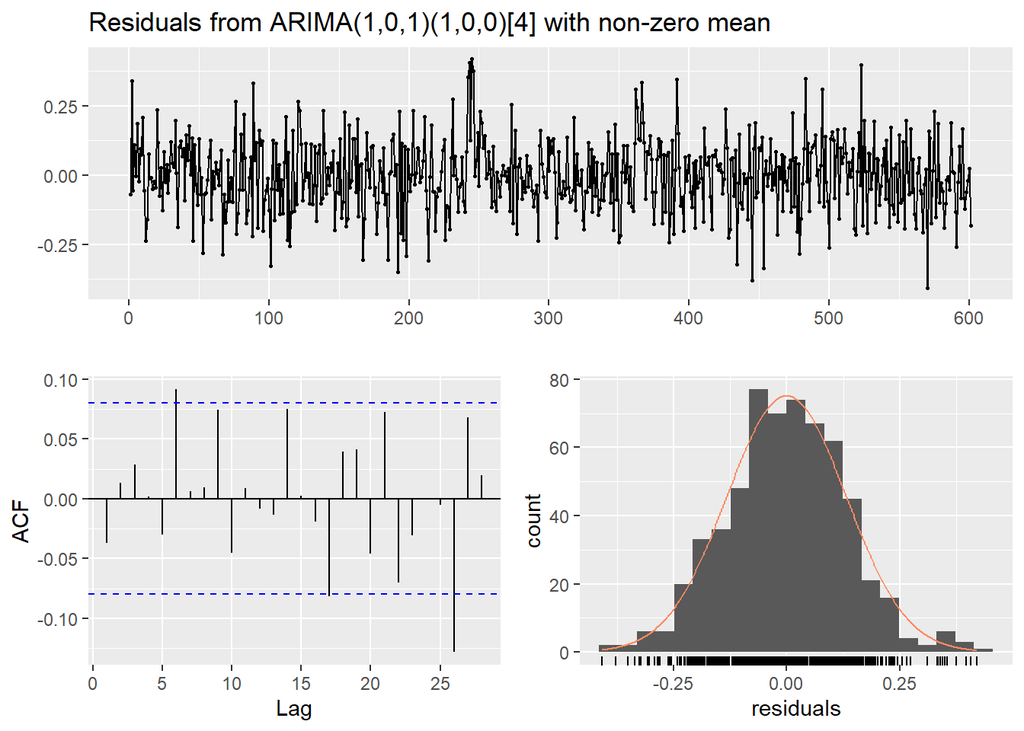

```
##
##  Ljung-Box test
##
## data:  Residuals from ARIMA(1,0,1)(1,0,0)[4] with non-zero mean
## Q* = 11.813, df = 6, p-value = 0.06628
##
## Model df: 4.   Total lags used: 10
```

```r
checkresiduals(mod3)
```

```r
#test incorrelazione
LjungBoxTest(residuals(mod3), k = 1, lag.max = 20)
```

```
##   m    Qm    pvalue
##   1  0.84 0.3594771
##   2  0.95 0.3301922
##   3  1.43 0.4887114
##   4  1.43 0.6976700
##   5  1.99 0.7374233
##   6  7.07 0.2152802
##   7  7.10 0.3118387
##   8  7.15 0.4130310
##   9 10.56 0.2280502
##  10 11.81 0.2240836
##  11 11.86 0.2946481
##  12 11.90 0.3712110
##  13 12.01 0.4446214
##  14 15.50 0.2772963
##  15 15.50 0.3447128
##  16 15.73 0.4005386
##  17 19.86 0.2265870
##  18 20.81 0.2349051
##  19 21.86 0.2381813
##  20 23.19 0.2290019
```

```r
#test normalità
jarque.bera.test(residuals(mod3))
```

```
##
##  Jarque Bera Test
##
## data:  residuals(mod3)
## X-squared = 1.9456, df = 2, p-value = 0.378
```

#Modello log con differenza prima Per tentare di correggere la correlazione inserisco una differenza prima

```r
mod4 <- Arima(ltsm, order = c(0, 1, 1))

summary(mod4)
```

```
## Series: ltsm
## ARIMA(0,1,1)
##
## Coefficients:
##           ma1
##       -0.7698
## s.e.   0.0259
##
## sigma^2 estimated as 0.01787:  log likelihood=356.15
## AIC=-708.3   AICc=-708.28   BIC=-699.51
##
## Training set error measures:
##                        ME      RMSE       MAE        MPE     MAPE      MASE
## Training set -0.001694447 0.1334401 0.1049462 -0.1223912 2.410197 0.7737577
##                     ACF1
## Training set -0.01271421
```

```r
coeftest(mod4)
```

```
##
## z test of coefficients:
##
##      Estimate Std. Error z value  Pr(>|z|)
## ma1 -0.769811   0.025908 -29.713 < 2.2e-16 ***
## ---
## Signif. codes:  0 '***' 0.001 '**' 0.01 '*' 0.05 '.' 0.1 ' ' 1
```

Inserendo la differenza prima l’unico coefficiente che resta significativo è quello a media mobile. I valori di MAPE e AIC non mostrano chissà che miglioramenti

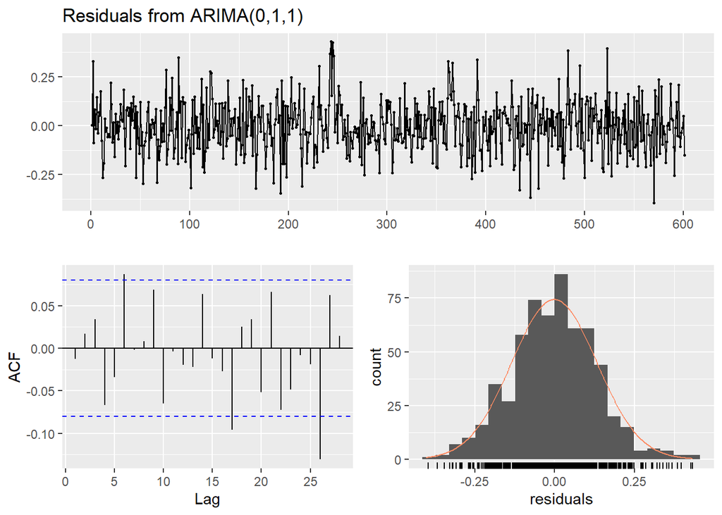

```
##
##  Ljung-Box test
##
## data:  Residuals from ARIMA(0,1,1)
## Q* = 14.545, df = 9, p-value = 0.1042
##
## Model df: 1.   Total lags used: 10
```

```r
checkresiduals(mod4)
```

```r
#test incorrelazione
LjungBoxTest(residuals(mod4), k = 1, lag.max = 20)
```

```
##   m    Qm     pvalue
##   1  0.10 0.75468266
##   2  0.27 0.60289991
##   3  0.98 0.61373193
##   4  3.68 0.29764453
##   5  4.40 0.35484225
##   6  9.00 0.10918756
##   7  9.00 0.17363783
##   8  9.04 0.24968695
##   9 11.93 0.15413637
##  10 14.55 0.10420263
##  11 14.56 0.14913297
##  12 14.79 0.19219206
##  13 15.10 0.23604228
##  14 17.63 0.17213212
##  15 17.72 0.22005168
##  16 18.18 0.25357167
##  17 23.88 0.09213371
##  18 24.28 0.11211856
##  19 25.00 0.12479237
##  20 26.69 0.11213042
```

```r
#test normalità
jarque.bera.test(residuals(mod4))
```

```
##
##  Jarque Bera Test
##
## data:  residuals(mod4)
## X-squared = 3.1035, df = 2, p-value = 0.2119
```

#Modello con differenza e stagionalità

```r
mod5 <- Arima(ltsm, order = c(0, 1, 1), seasonal = list(order = c(1,0,1), period = 4))

summary(mod5)
```

```
## Series: ltsm
## ARIMA(0,1,1)(1,0,1)[4]
##
## Coefficients:
##           ma1    sar1     sma1
##       -0.7603  0.8020  -0.8539
## s.e.   0.0267  0.1261   0.1084
##
## sigma^2 estimated as 0.0178:  log likelihood=358.26
## AIC=-708.51   AICc=-708.44   BIC=-690.92
##
## Training set error measures:
##                        ME      RMSE       MAE        MPE     MAPE      MASE
## Training set -0.002107562 0.1329592 0.1048462 -0.1334051 2.408357 0.7730206
##                     ACF1
## Training set -0.02346141
```

```r
coeftest(mod5)
```

```
##
## z test of coefficients:
##
##       Estimate Std. Error  z value  Pr(>|z|)
## ma1  -0.760256   0.026708 -28.4655 < 2.2e-16 ***
## sar1  0.802009   0.126110   6.3596 2.023e-10 ***
## sma1 -0.853863   0.108439  -7.8741 3.431e-15 ***
## ---
## Signif. codes:  0 '***' 0.001 '**' 0.01 '*' 0.05 '.' 0.1 ' ' 1
```

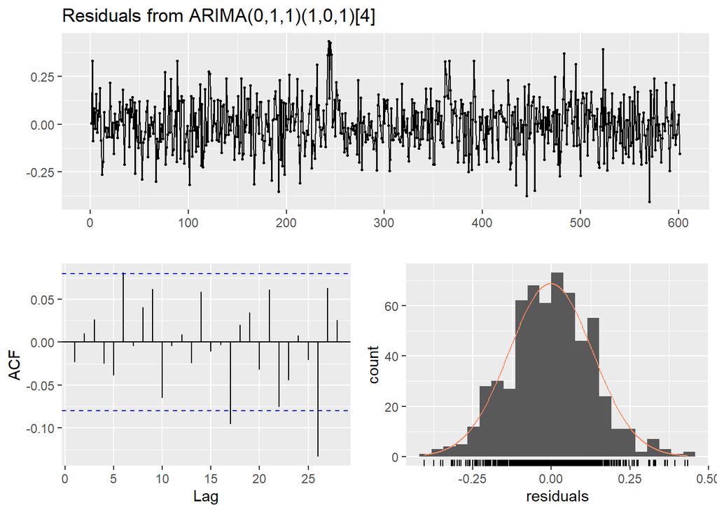

```
##
##  Ljung-Box test
##
## data:  Residuals from ARIMA(0,1,1)(1,0,1)[4]
## Q* = 12.058, df = 7, p-value = 0.09867
##
## Model df: 3.   Total lags used: 10
```

```r
checkresiduals(mod5)
```

```r
#test incorrelazione
LjungBoxTest(residuals(mod5), k = 1, lag.max = 20)
```

```
##   m    Qm    pvalue
##   1  0.33 0.5642100
##   2  0.39 0.5309034
##   3  0.81 0.6678894
##   4  1.19 0.7559094
##   5  2.11 0.7164154
##   6  6.08 0.2986770
##   7  6.09 0.4131102
##   8  7.11 0.4174305
##   9  9.46 0.3048299
##  10 12.06 0.2100604
##  11 12.07 0.2801534
##  12 12.12 0.3546328
##  13 12.50 0.4061487
##  14 14.62 0.3318457
##  15 14.69 0.3994471
##  16 14.70 0.4730781
##  17 20.35 0.2050811
##  18 20.60 0.2448650
##  19 21.32 0.2634060
##  20 21.97 0.2855855
```

```r
#test normalità
jarque.bera.test(residuals(mod5))
```

```
##
##  Jarque Bera Test
##
## data:  residuals(mod5)
## X-squared = 3.03, df = 2, p-value = 0.2198
```

#Modello con intervento sul 2017 Aggiungo una colonna al dataset con valore 1 quando siamo nel 2017 e 0 negli altri anni

```r
milano$int <- ifelse(year(milano$DATA) == "2017", 1, 0)
```

```r
mod6 <- Arima(tsm, order = c(1, 0, 1), xreg = milano$int)

summary(mod6)
```

```
## Series: tsm
## Regression with ARIMA(1,0,1) errors
##
## Coefficients:
##          ar1      ma1  intercept    xreg
##       0.9550  -0.7166    78.6245  5.4269
## s.e.  0.0155   0.0341     2.7617  4.2303
##
## sigma^2 estimated as 113.1:  log likelihood=-2272.06
## AIC=4554.12   AICc=4554.22   BIC=4576.11
##
## Training set error measures:
##                       ME     RMSE      MAE       MPE    MAPE      MASE
## Training set -0.05579027 10.59966 8.316972 -1.810109 10.6336 0.7743922
##                     ACF1
## Training set -0.02918241
```

```r
coeftest(mod6)
```

```
##
## z test of coefficients:
##
##            Estimate Std. Error  z value Pr(>|z|)
## ar1        0.955019   0.015458  61.7795   <2e-16 ***
## ma1       -0.716637   0.034128 -20.9983   <2e-16 ***
## intercept 78.624475   2.761670  28.4699   <2e-16 ***
## xreg       5.426854   4.230267   1.2829   0.1995
## ---
## Signif. codes:  0 '***' 0.001 '**' 0.01 '*' 0.05 '.' 0.1 ' ' 1
```

L’intervento non è significativo

#Modello solo per il 2019

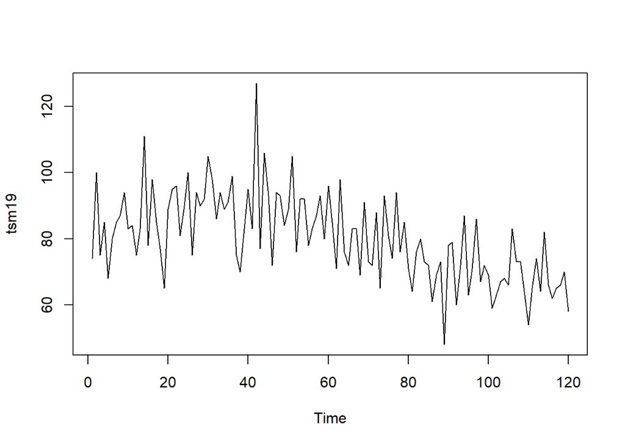

```r
milano19 <- milano[year(milano$DATA) == "2019", ]

tsm19 <- ts(milano19$DECESSI)

ts.plot(tsm19)
```

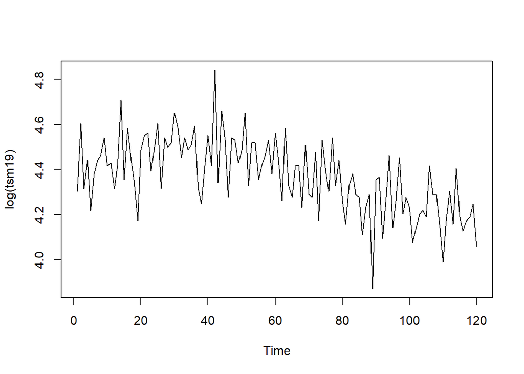

```r
ts.plot(log(tsm19))
```

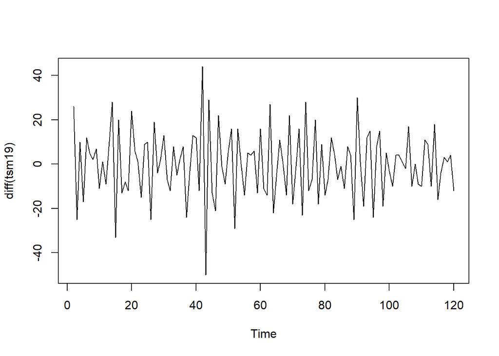

```r
ts.plot(diff(tsm19))
```

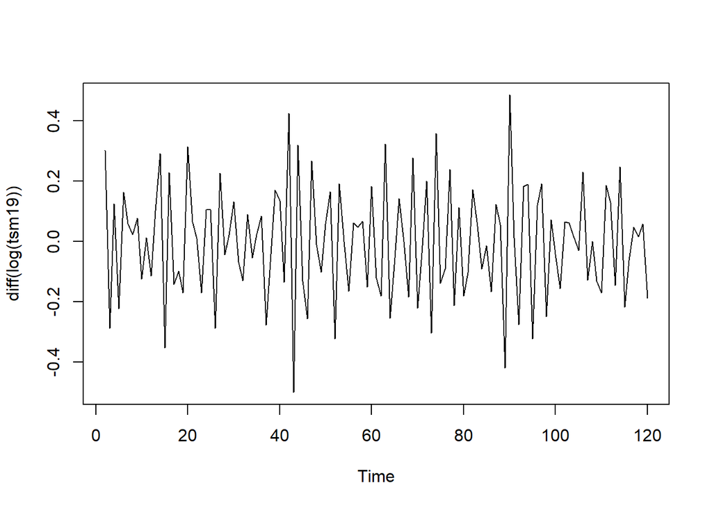

```r
ts.plot(diff(log(tsm19)))
```

La serie si nota non essere stazionaria in media, la trasformazione logaritmica (che serve a sistemare la non stazionarietà in varianza, ma si fa per prima dato che può sistemare anche quella in media) non sembra risolvere niente. Applicando la differenza prima la questione si sistema un po’, si nota un picco a inizio febbraio e inizio aprile. La combo trasformazione + differenza non risolve granchè.

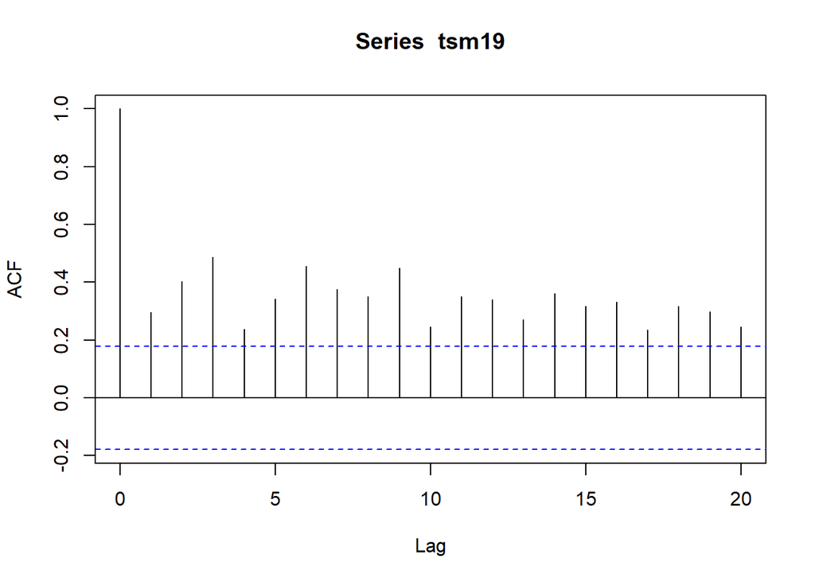

```r
acf(tsm19)
```

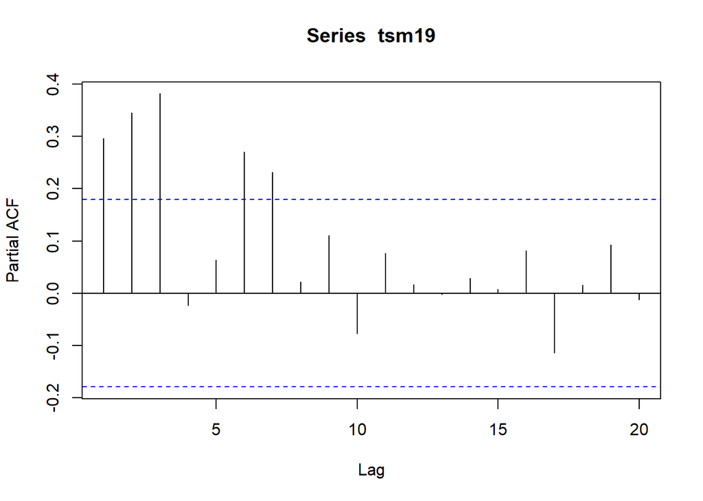

```r
pacf(tsm19)
```

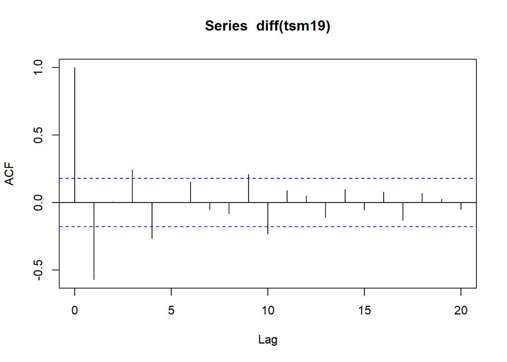

```r
acf(diff(tsm19))
```

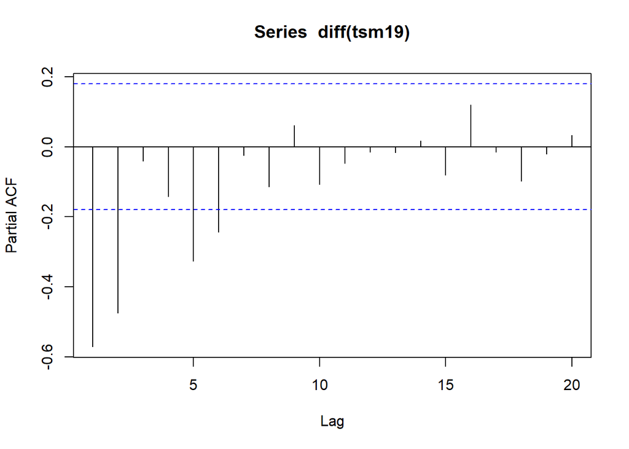

```r
pacf(diff(tsm19))
```

Andamento strano della pacf che cresce prima di annullarsi. Acf ha andamento stagionale. Con la differenza si vede acf che si annulla al quarto lag con andamento alternato e pacf negativa che si annulla al secondo lag. L’alternarsi delle barrette consiglia il modello AR

```r
mod7 <- Arima(tsm19, order = c(2, 1, 0))

summary(mod7)
```

```
## Series: tsm19
## ARIMA(2,1,0)
##
## Coefficients:
##           ar1      ar2
##       -0.8568  -0.4822
## s.e.   0.0804   0.0807
##
## sigma^2 estimated as 122.7:  log likelihood=-454.49
## AIC=914.98   AICc=915.19   BIC=923.32
##
## Training set error measures:
##                      ME     RMSE      MAE       MPE     MAPE      MASE
## Training set -0.3053002 10.93759 8.674914 -1.856958 10.97607 0.7013008
##                     ACF1
## Training set -0.01925734
```

```r
coeftest(mod7)
```

```
##
## z test of coefficients:
##
##      Estimate Std. Error  z value  Pr(>|z|)
## ar1 -0.856780   0.080425 -10.6532 < 2.2e-16 ***
## ar2 -0.482243   0.080702  -5.9756 2.292e-09 ***
## ---
## Signif. codes:  0 '***' 0.001 '**' 0.01 '*' 0.05 '.' 0.1 ' ' 1
```

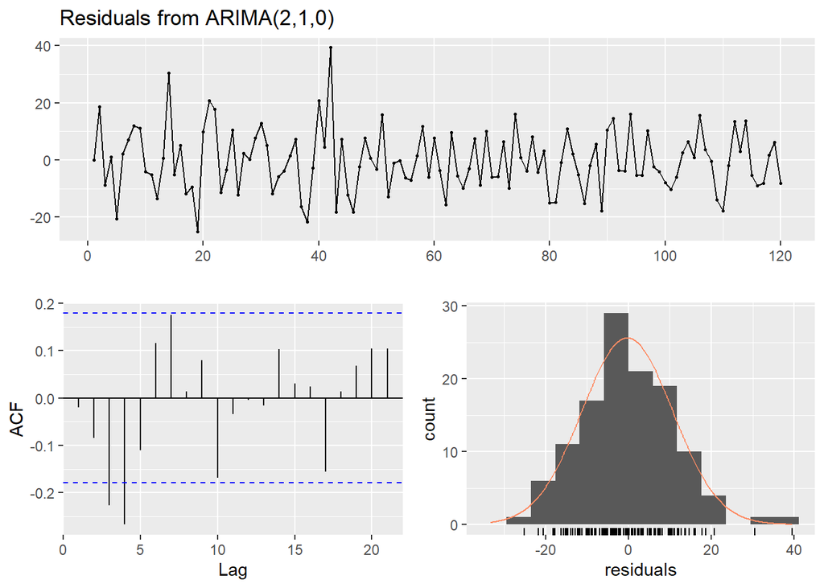

```
##
##  Ljung-Box test
##
## data:  Residuals from ARIMA(2,1,0)
## Q* = 28.385, df = 8, p-value = 0.0004064
##
## Model df: 2.   Total lags used: 10
```

```r
checkresiduals(mod7)
```

```r
#test incorrelazione
LjungBoxTest(residuals(mod7), k = 1, lag.max = 20)
```

```
##   m    Qm       pvalue
##   1  0.05 0.8308620617
##   2  0.95 0.3308684910
##   3  7.41 0.0245914369
##   4 16.42 0.0009299135
##   5 17.96 0.0012580010
##   6 19.70 0.0014209272
##   7 23.71 0.0005907514
##   8 23.73 0.0012683294
##   9 24.58 0.0018314337
##  10 28.38 0.0008224566
##  11 28.54 0.0014811573
##  12 28.54 0.0026759151
##  13 28.57 0.0045554895
##  14 30.04 0.0046450355
##  15 30.17 0.0072321783
##  16 30.25 0.0110562937
##  17 33.70 0.0059661629
##  18 33.73 0.0091048839
##  19 34.41 0.0112095001
##  20 36.00 0.0105435143
```

```r
#test normalità
jarque.bera.test(residuals(mod7))
```

```
##
##  Jarque Bera Test
##
## data:  residuals(mod7)
## X-squared = 6.914, df = 2, p-value = 0.03152
```

#Modello solo per il 2019 con trasformata logaritmica

```r
mod8 <- Arima(log(tsm19), order = c(2, 1, 0))

summary(mod8)
```

```
## Series: log(tsm19)
## ARIMA(2,1,0)
##
## Coefficients:
##           ar1      ar2
##       -0.8290  -0.5039
## s.e.   0.0795   0.0796
##
## sigma^2 estimated as 0.01854:  log likelihood=68.97
## AIC=-131.94   AICc=-131.73   BIC=-123.6
##
## Training set error measures:
##                        ME      RMSE       MAE        MPE     MAPE      MASE
## Training set -0.004118222 0.1344327 0.1077443 -0.1712706 2.470216 0.7020116
##                     ACF1
## Training set -0.02176674
```

```r
coeftest(mod8)
```

```
##
## z test of coefficients:
##
##      Estimate Std. Error  z value  Pr(>|z|)
## ar1 -0.828971   0.079458 -10.4328 < 2.2e-16 ***
## ar2 -0.503916   0.079577  -6.3325 2.413e-10 ***
## ---
## Signif. codes:  0 '***' 0.001 '**' 0.01 '*' 0.05 '.' 0.1 ' ' 1
```

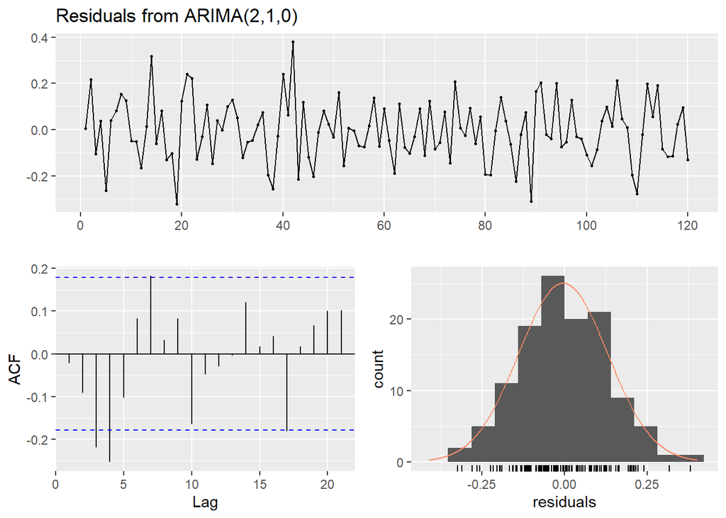

```
##
##  Ljung-Box test
##
## data:  Residuals from ARIMA(2,1,0)
## Q* = 26.292, df = 8, p-value = 0.0009358
##
## Model df: 2.   Total lags used: 10
```

```r
checkresiduals(mod8)
```

```r
#test incorrelazione
LjungBoxTest(residuals(mod8), k = 1, lag.max = 20)
```

```
##   m    Qm      pvalue
##   1  0.06 0.809222167
##   2  1.09 0.295723485
##   3  7.06 0.029372818
##   4 15.13 0.001708254
##   5 16.46 0.002456292
##   6 17.35 0.003877723
##   7 21.64 0.001408376
##   8 21.77 0.002783472
##   9 22.67 0.003809508
##  10 26.29 0.001829509
##  11 26.60 0.003009697
##  12 26.72 0.005072843
##  13 26.72 0.008482407
##  14 28.73 0.007156496
##  15 28.77 0.011233303
##  16 29.01 0.016054238
##  17 33.65 0.006057893
##  18 33.69 0.009211577
##  19 34.32 0.011481769
##  20 35.79 0.011198204
```

```r
#test normalità
jarque.bera.test(residuals(mod8))
```

```
##
##  Jarque Bera Test
##
## data:  residuals(mod8)
## X-squared = 0.20795, df = 2, p-value = 0.9012
```

Tutto considerato penso che il modello 2 sia il modello migliore, ma la cosa della correlazione è da studiarsela meglio.

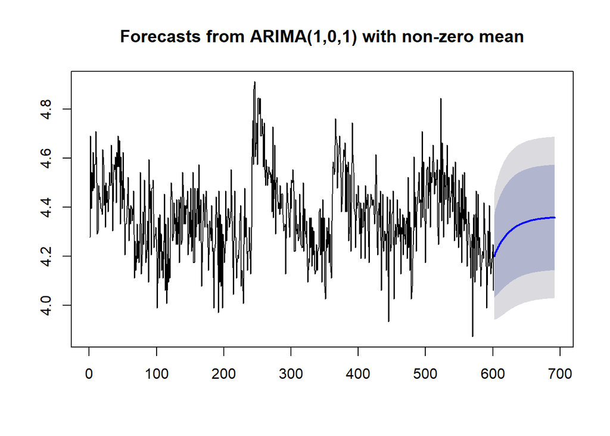

```r
h_fut <- 91
previsioni = forecast(mod2, h = h_fut)
plot(previsioni)
```

```r
newdays <- seq(as.Date("2020-01-01"), as.Date("2020-03-31"), by="days")
prev_ci <- data.frame(DATA = newdays, MEDIA = round(exp(previsioni$mean)), LB95 = round(exp(previsioni$lower[,2])), UB95 = round(exp(previsioni$upper[,2]))); prev_ci
```

```
##          DATA MEDIA LB95 UB95
## 1  2020-01-01    67   51   87
## 2  2020-01-02    67   51   88
## 3  2020-01-03    68   52   89
## 4  2020-01-04    68   52   90
## 5  2020-01-05    68   52   91
## 6  2020-01-06    69   52   92
## 7  2020-01-07    69   52   92
## 8  2020-01-08    70   52   93
## 9  2020-01-09    70   52   94
## 10 2020-01-10    70   52   95
## 11 2020-01-11    71   52   95
## 12 2020-01-12    71   52   96
## 13 2020-01-13    71   52   97
## 14 2020-01-14    71   52   97
```

[output cut: 77 more lines]

```r
i = 0
aux = 0
ar = 0
for (val in tsm){
    if(i == 7){
        ar = c(ar, aux)
        i = 0
        aux = 0
    }
    aux = aux + val
    i = i + 1
}

ar
```

```
##  [1]   0 633 631 610 586 625 667 658 571 569 505 510 519 541 548 481 490 451 547
## [20] 535 551 551 544 540 534 565 511 493 491 494 538 530 479 478 496 648 808 787
## [39] 675 659 615 585 539 571 566 522 523 479 483 494 494 481 562 715 667 655 606
## [58] 573 545 553 558 597 520 513 501 520 531 507 531 493 574 612 588 646 632 641
## [77] 630 601 578 559 568 497 479 515 479 476
```

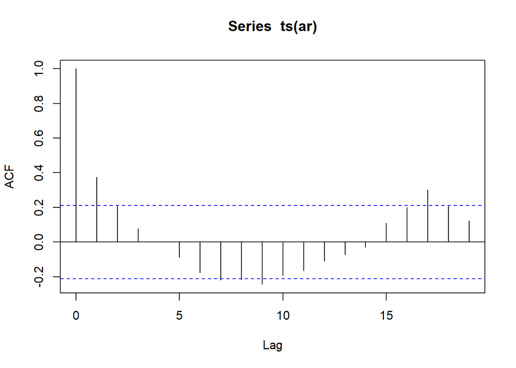

```r
acf(ts(ar))
```

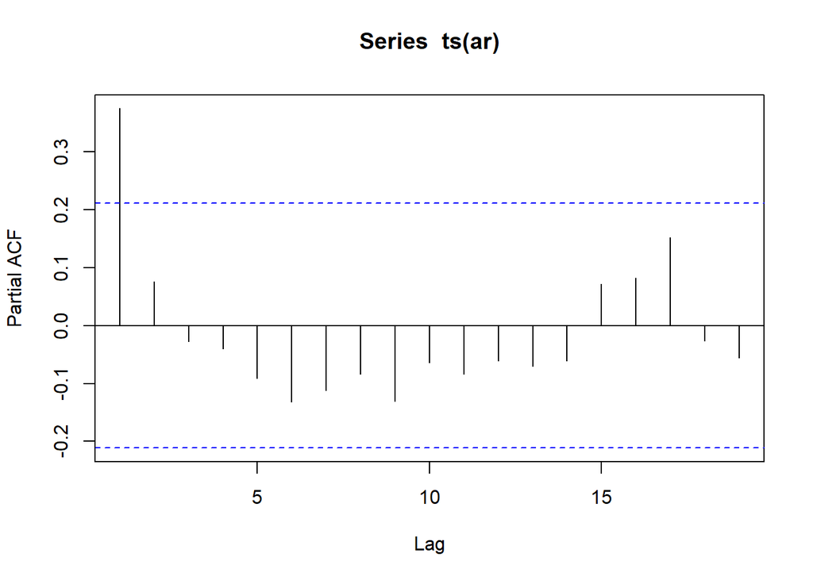

```r
pacf(ts(ar))
```

```r
mod9 <- Arima(log(ar[-1]), order = c(2, 0, 0))

summary(mod9)
```

```
## Series: log(ar[-1])
## ARIMA(2,0,0) with non-zero mean
##
## Coefficients:
##          ar1      ar2    mean
##       0.9590  -0.2424  6.3207
## s.e.  0.1045   0.1059  0.0273
##
## sigma^2 estimated as 0.005495:  log likelihood=101.57
## AIC=-195.15   AICc=-194.65   BIC=-185.38
##
## Training set error measures:
##                       ME       RMSE        MAE         MPE     MAPE      MASE
## Training set -0.00104134 0.07280586 0.05265451 -0.02971138 0.831168 0.9359824
##                     ACF1
## Training set -0.02789122
```

```r
coeftest(mod9)
```

```
##
## z test of coefficients:
##
##            Estimate Std. Error  z value Pr(>|z|)
## ar1        0.959029   0.104513   9.1762  < 2e-16 ***
## ar2       -0.242449   0.105865  -2.2902  0.02201 *
## intercept  6.320739   0.027332 231.2610  < 2e-16 ***
## ---
## Signif. codes:  0 '***' 0.001 '**' 0.01 '*' 0.05 '.' 0.1 ' ' 1
```

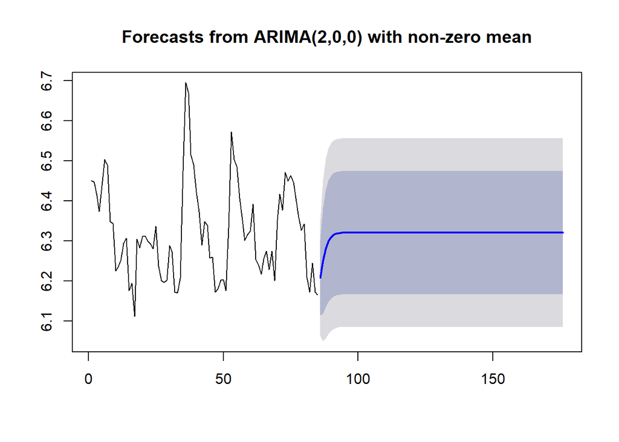

```r
h_fut <- 91
previsioni = forecast(mod9, h = h_fut)
plot(previsioni)
```

```r
newdays <- seq(as.Date("2020-01-01"), as.Date("2020-03-31"), by="days")
prev_ci <- data.frame(DATA = newdays, MEDIA = round(exp(previsioni$mean)), LB95 = round(exp(previsioni$lower[,2])), UB95 = round(exp(previsioni$upper[,2]))); prev_ci
```

```
##          DATA MEDIA LB95 UB95
## 1  2020-01-01   497  430  574
## 2  2020-01-02   518  424  634
## 3  2020-01-03   534  427  668
## 4  2020-01-04   544  431  686
## 5  2020-01-05   550  435  695
## 6  2020-01-06   553  437  700
## 7  2020-01-07   555  438  702
## 8  2020-01-08   555  439  703
## 9  2020-01-09   556  439  703
## 10 2020-01-10   556  439  704
## 11 2020-01-11   556  439  704
## 12 2020-01-12   556  439  704
## 13 2020-01-13   556  439  704
## 14 2020-01-14   556  439  704
```

[output cut: 77 more lines]

```r
milano20 <- Lombardia %>% dplyr::filter(NOME_PROVINCIA == "Milano",  DATA >= "2020-01-01") %>%
  select(DATA, DECESSI); milano20
```

```
##          DATA DECESSI
## 1  2020-01-01      88
## 2  2020-01-02      81
## 3  2020-01-03      80
## 4  2020-01-04      69
## 5  2020-01-05      73
## 6  2020-01-06      81
## 7  2020-01-07      74
## 8  2020-01-08      77
## 9  2020-01-09      84
## 10 2020-01-10      89
## 11 2020-01-11      65
## 12 2020-01-12      69
## 13 2020-01-13      72
## 14 2020-01-14      97
```

[output cut: 81 more lines]

```r
milano_prev <- merge(milano20, prev_ci, by = 'DATA'); milano_prev
```

```
##          DATA DECESSI MEDIA LB95 UB95
## 1  2020-01-01      88   497  430  574
## 2  2020-01-02      81   518  424  634
## 3  2020-01-03      80   534  427  668
## 4  2020-01-04      69   544  431  686
## 5  2020-01-05      73   550  435  695
## 6  2020-01-06      81   553  437  700
## 7  2020-01-07      74   555  438  702
## 8  2020-01-08      77   555  439  703
## 9  2020-01-09      84   556  439  703
## 10 2020-01-10      89   556  439  704
## 11 2020-01-11      65   556  439  704
## 12 2020-01-12      69   556  439  704
## 13 2020-01-13      72   556  439  704
## 14 2020-01-14      97   556  439  704
```

[output cut: 77 more lines]

```r
milano_prev$diff <- milano_prev$DECESSI - milano_prev$MEDIA
milano_prev
```

```
##          DATA DECESSI MEDIA LB95 UB95 diff
## 1  2020-01-01      88   497  430  574 -409
## 2  2020-01-02      81   518  424  634 -437
## 3  2020-01-03      80   534  427  668 -454
## 4  2020-01-04      69   544  431  686 -475
## 5  2020-01-05      73   550  435  695 -477
## 6  2020-01-06      81   553  437  700 -472
## 7  2020-01-07      74   555  438  702 -481
## 8  2020-01-08      77   555  439  703 -478
## 9  2020-01-09      84   556  439  703 -472
## 10 2020-01-10      89   556  439  704 -467
## 11 2020-01-11      65   556  439  704 -491
## 12 2020-01-12      69   556  439  704 -487
## 13 2020-01-13      72   556  439  704 -484
## 14 2020-01-14      97   556  439  704 -459
```

[output cut: 77 more lines]

```r
sum(milano_prev$diff)
```

```
## [1] -41345
```